**Table: Dermatology Life Quality Index (DLQI)** measures from 12 alopecia areata studies<sup>1</sup>

DLQI is measured from 0-30 with the latter indicating more severe impairment

Study Number  
Reference

Demographics

Statistics

**DLQI** Displays

Age  
(yr)

Female  
(%)

Sample  
Size

5-number summary  
Q1-■Median-Q3 Mean→SD

Density Dot Plot (Simulated)  
**0 5 10 15 20 25 30**

3

Andersen et al.94

51

67.1%

1494

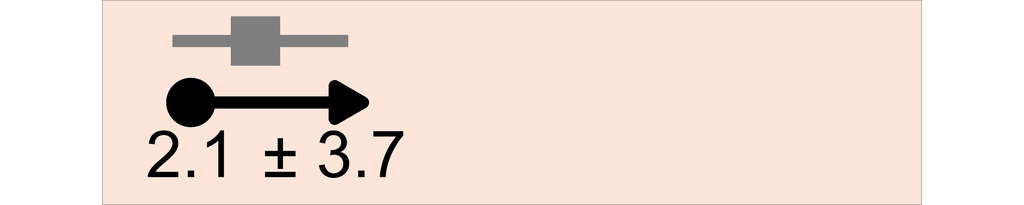

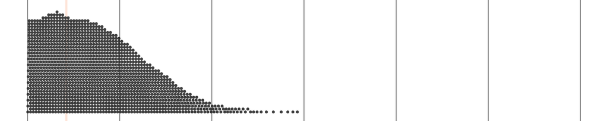

2

Ferentinos et al.95

43

63.5%

52

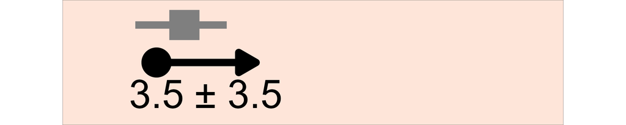

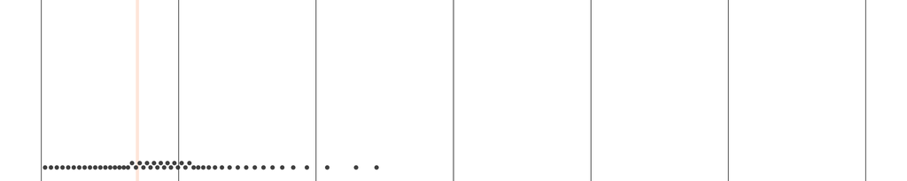

1

Ito et al.22

43

67.3%

400

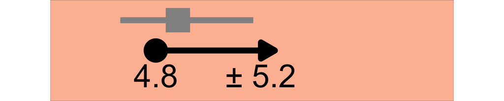

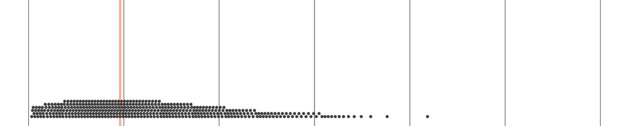

10

Qi et al.20

39

50.0%

698

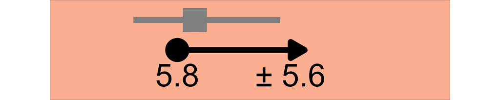

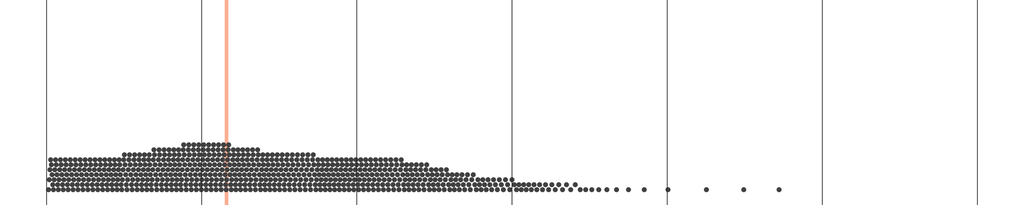

5

Velez-Muniz et al.13

—

56.0%

126

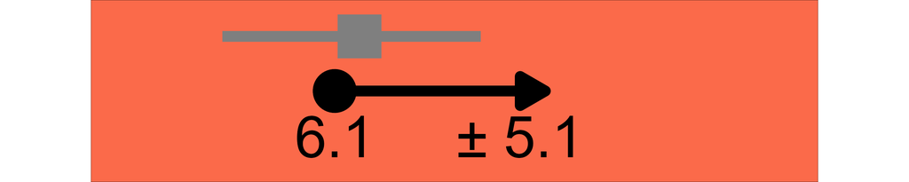

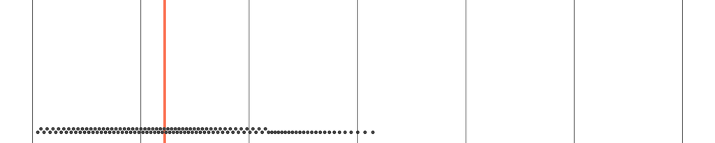

12

Ghajarzadeh et al.100

23

31.0%

100

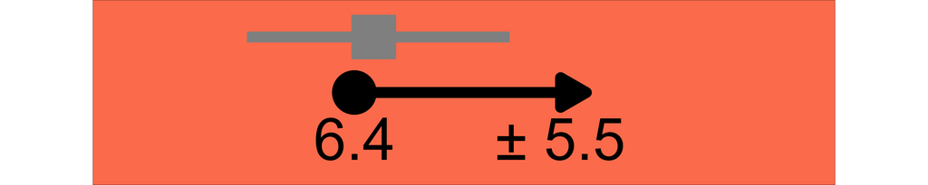

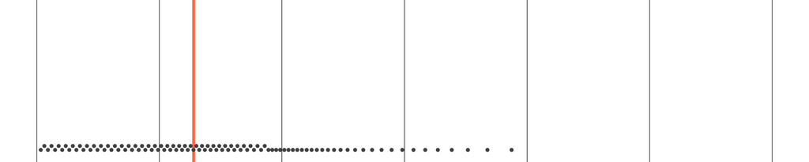

11

Shi et al.29

—

73.0%

532

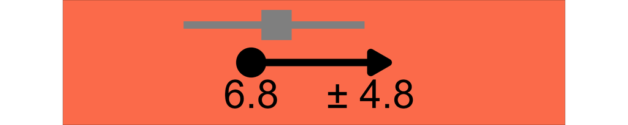

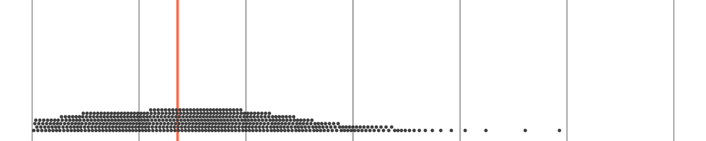

9

Yu et al.32

32

58.5%

130

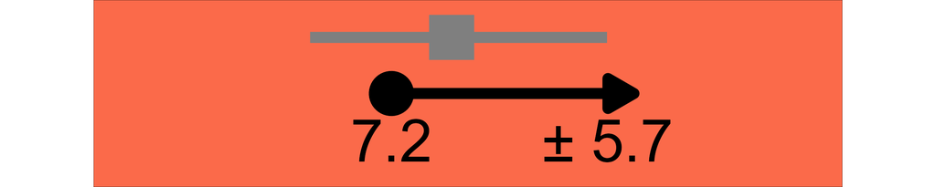

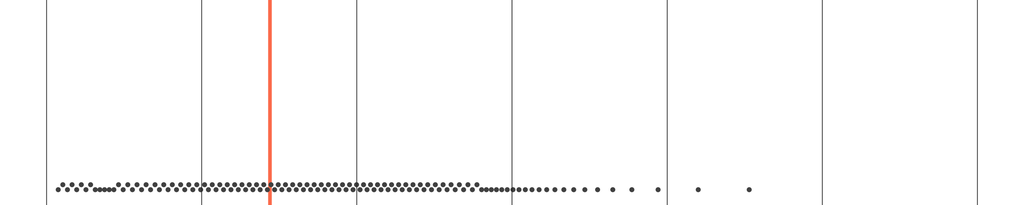

7

Liu et al.27

41

65.6%

292

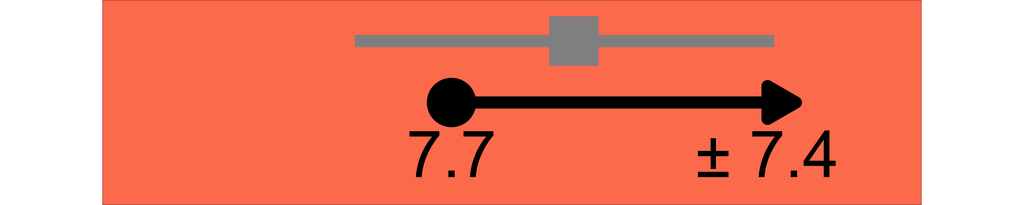

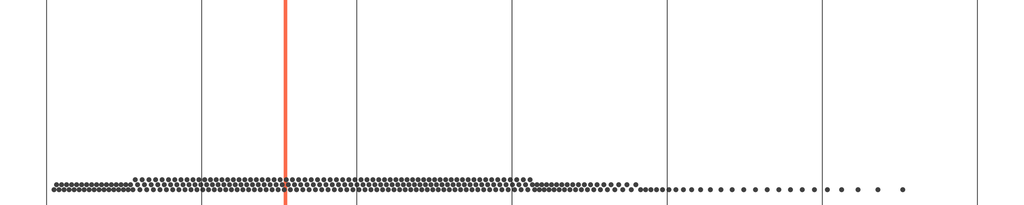

6

Abedini et al.19

31

12.5%

176

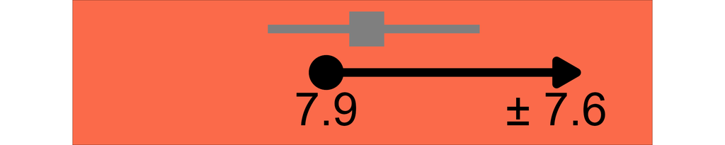

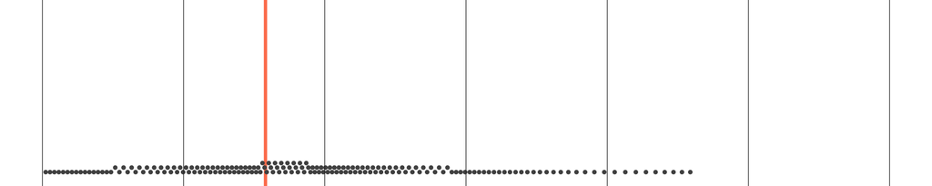

8

Zhang et al.16

—

—

55

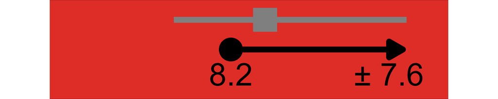

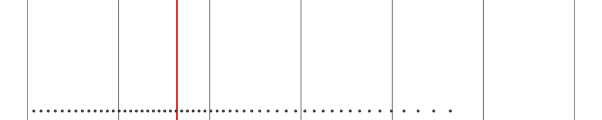

4

Nasimi et al.90

29

35.0%

100

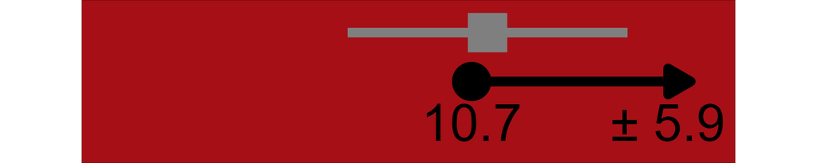

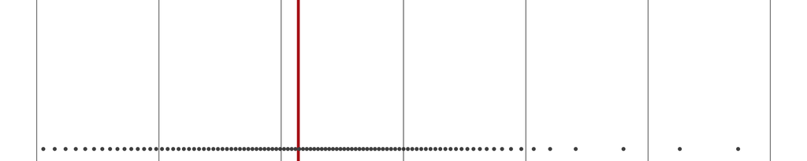

**References**

**94.** Andersen YMF, Nymand L, DeLozier AM, et al. Patient characteristics and disease burden of alopecia areata in the Danish Skin Cohort. BMJ Open 2022; 12: e053137.  
**95.** Ferentinos P, Kalogeropoulou E, Pappa G, et al. Assessing the role of stressful life events in the induction and recurrence of alopecia areata: A case-control study. J Am Acad Dermatol. Epub ahead of print 24 March 2022. DOI: 10.1016/j.jaad.2022.03.036.  
**22.** Ito T, Kamei K, Yuasa A, et al. Health-related quality of life in patients with alopecia areata: Results of a Japanese survey with norm-based comparisons. J Dermatol 2022; 49:584-593.  
**20.** Qi S, Xu F, Sheng Y, et al. Assessing quality of life in Alopecia areata patients in China. Psychol Health Med 2015; 20: 97-102.  
**13.** Vélez-Muñiz R d. C, Peralta-Pedrero ML, Jurado-Santa Cruz F, et al. Psychological Profile and Quality of Life of Patients with Alopecia Areata. Skin Appendage Disorders 2019; 5:293-298.  
**100.** Ghajarzadeh M, Ghiasi M, Kheirkhah S. Associations between skin diseases and quality of life: a comparison of psoriasis, vitiligo, and alopecia areata. Acta Med Iran 2012; 50:511-515.  
**29.** Shi Q, Duvic M, Osei JS, et al. Health-Related Quality of Life (HRQoL) in Alopecia Areata Patients-A Secondary Analysis of the National Alopecia Areata Registry Data. J Investig Dermatol Symp Proc 2013; 16: S49-S50.  
**32.** Yu N-L, Tan H, Song Z-Q, et al. Illness perception in patients with androgenetic alopecia and alopecia areata in China. Journal of Psychosomatic Research 2016; 86: 1-6.  
**27.** Liu LY, Craiglow BG, King BA. Successful treatment of moderate-to-severe alopecia areata improves health-related quality of life. J Am Acad Dermatol 2018; 78: 597-599.e2.  
**19.** Abedini R, Hallaji Z, Lajevardi V, et al. Quality of life in mild nd severe alopecia areata patients. Int J Womens Dermatol 2018; 4: 91-94.  
**16.** Zhang M, Zhang N. Quality of life assessment in patients with alopecia areata and androgenetic alopecia in the People's Republic of China. Patient Prefer Adherence 2017;11: 151-155.  
**90.** Nasimi M, Ghandi N, Torabzade L, et al. Alopecia Areata-Quality of Life Index Questionnaire (Reliability and Validity of the Persian Version) in Comparison to Dermatology Life Quality Index. Int J Trichology 2020; 12: 227-233.

<sup>1</sup> [Muntyanu, Anastasiya, et al. **The burden of alopecia areata: A scoping review focusing on quality of life, mental health and work productivity.** Journal of the European Academy of Dermatology and Venereology (2023).](https://onlinelibrary.wiley.com/doi/abs/10.1111/jdv.18926)